# Project- American Sign Language Hand Gesture Recognition

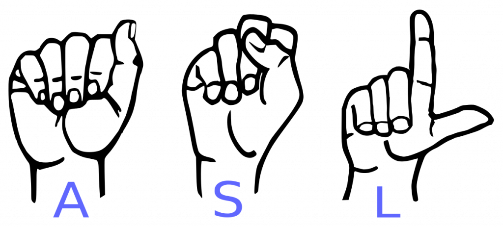

## Project Overview & aims

While there are new and accessible technologies emerging to help those with hearing disabilities, there is still plenty of work to be done. For example, Deep learning algorithms could help the deaf and hard-of-hearing even further by offering ways to better communicate using computer vision applications. Our project aims to do just that.

We sought to create a system that is capable of identifying American Sign Language (ASL) hand gestures.

## Project Summary

### Goal:

Build a system that can correctly identify American Sign Language signs that corresponds to the hand gestures

### Method:

The static sign language data for our project was in the form of images. We trained a Convolutional Neural Network (CNN) to identify the signs represented by each of these images.

### Applications:

Our proposed system will help the deaf and hard-of-hearing communicate better with members of the community. For example, there have been incidents where those who are deaf have had trouble communicating with first responders when in need. Although responders may receive training on the basics of ASL, it is unrealistic to expect everyone to become fully fluent in sign language. Down the line, advancements like these in computer recognition could aid a first responder in understanding and helping those that are unable to communicate through speech.

Another application is to enable the deaf and hard-of-hearing equal access to video consultations, whether in a professional context or while trying to communicate with their healthcare providers via telehealth. Instead of using basic chat, these advancements would allow the hearing-impaired access to effective video communication.

### Ref:

https://keras.io/preprocessing/image/

https://medium.com/@vijayabhaskar96/tutorial-image-classification-with-keras-flow-from-directory-and-generators-95f75ebe5720

https://towardsdatascience.com/american-sign-language-hand-gesture-recognition-f1c4468fb177

https://towardsdatascience.com/visualizing-intermediate-activation-in-convolutional-neural-networks-with-keras-260b36d60d0 (Displaying curves of loss and accuracy during training)

https://github.com/gabrielpierobon/cnnshapes/blob/master/README.md (Visualizing intermediate activation in Convolutional Neural Networks with Keras) https://www.kaggle.com/amarjeet007/visualize-cnn-with-keras

https://towardsdatascience.com/overfitting-vs-underfitting-a-complete-example-d05dd7e19765

# Data Collection & Pre-Processing

### importing Packages & Library

```python
import tensorflow as tf
import keras

#Generate batches of tensor image data with real-time data augmentation. The data will be looped over (in batches).
from keras.preprocessing.image import ImageDataGenerator
```

```python
#validation_split: Float. Fraction of images reserved for validation (strictly between 0 and 1).
train_dg = ImageDataGenerator(validation_split=0.1)

#flow_from_directory: Takes the path to a directory & generates batches of augmented data.
##flow_from_directory(directory, target_size=(256, 256), batch_size=32,class_mode='categorical',subset=None)
#directory: The directory must be set to the path where your ‘n’ classes of folders are present.
#target_Size: Tuple of integers (height, width), default: (256, 256). The dimensions to which all images found will be resized.
#Class_mode: Determines the type of label arrays that are returned
##One of "categorical", "binary", "sparse", "input", or None. Default: "categorical"
##categorical will be 2D one-hot encoded labels,#binary-if you have only two classes to predict,#sparse will be 1D integer labels
##input" will be images identical to input images (mainly used to work with autoencoders).
##if none: the data still needs to reside in a subdirectory of directory for it to work correctly, no labels are returned
#Batch_Size: No. of images to be yielded from the generator per batch
#subset: Subset of data ("training" or "validation") if validation_split is set in ImageDataGenerator.
train_generator=train_dg.flow_from_directory(r'C:\Users\Radhakrishna/asl_alphabet_train',
                                             target_size=(200, 200),batch_size=15,
                                             class_mode='categorical',subset='training')
```

```
Found 37060 images belonging to 29 classes.
```

```python
#next()-the generator in a position to yield the second element
x_train,y_train=train_generator.next()

print(x_train.shape)
#print(x_train.size)
#one hot vector
print(y_train.shape)
#print(y_train.size)
```

```
(15, 200, 200, 3)
(15, 29)
```

```
(15, 200, 200, 3)
```

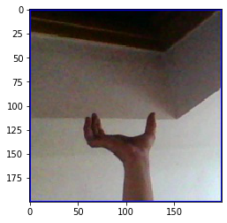

```python
#importing pyplot from matplot pakage
from matplotlib import pyplot
#imshow is attribute of pyplot which use to show image
pyplot.imshow(x_train[14,:,:].astype('int'))
print(x_train.shape)
pyplot.show()
```

```python
validation_generator = train_dg.flow_from_directory(r'C:\Users\Radhakrishna/asl_alphabet_train',
                                                    target_size=(200, 200),batch_size=15,
                                                    class_mode='categorical',subset='validation')
#next()-the generator in a position to yield the second element
x_val,y_val=validation_generator.next()

print(x_val.shape)
print(x_val[0].size)
print(y_val.shape)
print(y_val[0])
```

```
Found 4107 images belonging to 29 classes.
(15, 200, 200, 3)
120000
(15, 29)
[0. 1. 0. 0. 0. 0. 0. 0. 0. 0. 0. 0. 0. 0. 0. 0. 0. 0. 0. 0. 0. 0. 0. 0.
 0. 0. 0. 0. 0.]
```

```
(15, 200, 200, 3)
```

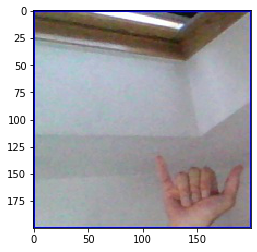

```python
#importing pyplot from matplot pakage
from matplotlib import pyplot
#imshow is attribute of pyplot which use to show image
pyplot.imshow(x_val[14].astype('int'))
print(x_val.shape)
pyplot.show()
```

# Learning/Modeling

[figure not shown]

The main advantage of CNN compared to its predecessors is that it automatically detects the important features without any human supervision.

Conv2D: This layer creates a convolution kernel that is convolved with the layer input to produce a tensor of outputs. If use_bias is True, a bias vector is created and added to the outputs. Finally, if activation is not None, it is applied to the outputs as well. When using this layer as the first layer in a model, provide the keyword argument input_shape.

strides: An integer or tuple/list of 2 integers, specifying the strides of the convolution along the height and width. Can be a single integer to specify the same value for all spatial dimensions. Specifying any stride value != 1 is incompatible with specifying any dilation_rate value != 1.

padding: one of "valid" or "same" (case-insensitive). Note that "same" is slightly inconsistent across backends with strides != 1, as described

Relu: Rectified Linear Unit_With default values, it returns element-wise max(x, 0).

MaxPooling2D: Max pooling operation for spatial data.

pool_size: integer or tuple of 2 integers, factors by which to downscale (vertical, horizontal). (2, 2) will halve the input in both spatial dimension.

Padding: "valid" means "no padding", "same" results in padding the input such that the output has the same length as the original input.

Flattens: Does not affect the batch size.Flattening is converting the data into a 1-dimensional array for inputting it to the next layer

Dense: NN layer, represents a matrix vector multiplication,(assuming your batch size is 1) The values in the matrix are the trainable parameters which get updated during backpropagation. So you get a m dimensional vector as output. A dense layer thus is used to change the dimensions of your vector.

```python
#The Sequential model is a linear stack of layers.
from keras.models import Sequential
#importing Hidden layers libraries from layers
from keras.layers import Conv2D,MaxPooling2D
from keras.layers import Flatten,Dense,BatchNormalization
#all the adding layer will be related to sequential
model=Sequential()
#the first layer can receive an `input_shape` argument:
model.add(Conv2D(32,(8,8),padding='same',activation="relu",input_shape=(200,200,3)))
model.add(MaxPooling2D(pool_size=(2,2)))
model.add(Conv2D(48,(5,5),padding="valid",strides=1,name="Conv2a",activation="relu"))
model.add(BatchNormalization())
model.add(MaxPooling2D(pool_size=(2,2)))
model.add(Conv2D(64,(3,3),padding="valid",strides=1,name="Conv2b",activation="relu"))
model.add(MaxPooling2D(pool_size=(2,2)))
model.add(Flatten())
model.add(Dense(50,activation ="relu"))
model.add(Dense(35,activation="relu"))
#dense layer will be a last layer t.e output(total 29 neurons as per class/features)
model.add(Dense(29,activation ="softmax"))
#prints a summary representation of model
model.summary()
```

```
Model: "sequential_37"
_________________________________________________________________
Layer (type)                 Output Shape              Param #
=================================================================
conv2d_35 (Conv2D)           (None, 200, 200, 32)      6176
_________________________________________________________________
max_pooling2d_73 (MaxPooling (None, 100, 100, 32)      0
_________________________________________________________________
Conv2a (Conv2D)              (None, 96, 96, 48)        38448
_________________________________________________________________
batch_normalization_26 (Batc (None, 96, 96, 48)        192
_________________________________________________________________
max_pooling2d_74 (MaxPooling (None, 48, 48, 48)        0
_________________________________________________________________
Conv2b (Conv2D)              (None, 46, 46, 64)        27712
_________________________________________________________________
max_pooling2d_75 (MaxPooling (None, 23, 23, 64)        0
_________________________________________________________________
flatten_25 (Flatten)         (None, 33856)             0
_________________________________________________________________
dense_73 (Dense)             (None, 50)                1692850
_________________________________________________________________
dense_74 (Dense)             (None, 35)                1785
_________________________________________________________________
dense_75 (Dense)             (None, 29)                1044
=================================================================
Total params: 1,768,207
Trainable params: 1,768,111
Non-trainable params: 96
_________________________________________________________________
```

### Compiling the model

optimizers: Adadelta:-is a more robust extension of Adagrad that adapts learning rates based on a moving window of gradient updates,instead of accumulating all past gradients.This way, Adadelta continues learning even when many updates have been done. Compared to Adagrad, in the original version of Adadelta you don't have to set an initial learning rate. In this version, initial learning rate and decay factor can be set, as in most other Keras optimizers.(leave at default value)

loss: A loss function. This is the objective that the model will try to minimize. It can be the string identifier of an existing loss function (such as categorical_crossentropy or mse), or it can be an objective function

metrics: A list of metrics. For any classification problem you will want to set this to metrics=['accuracy']. A metric could be the string identifier of an existing metric or a custom metric function.A metric is a function that is used to judge the performance of your model. Metric functions are to be supplied in the metrics parameter when a model is compiled

```python
#model copile: Configures the model for training or compile the model.
model.compile(loss = keras.losses.categorical_crossentropy,optimizer = keras.optimizers.Adadelta(),metrics =['accuracy'])
```

# Fitting/Training the model

```python
#This builds the model for the first time:
History1=model.fit_generator(train_generator,steps_per_epoch=2471, epochs=10, verbose=1,validation_data=validation_generator)
```

[output not shown]

```python
model.save('ASLC_using_CNN.h10')#training acc-99,loss-0.0052,val acc-63,loss-2.73
```

```python
"""#The Sequential model is a linear stack of layers.
from keras.models import Sequential
#importing Hidden layers libraries from layers
from keras.layers import Conv2D,MaxPooling2D
from keras.layers import Flatten,Dense
#all the adding layer will be related to sequential
model=Sequential()
#the first layer can receive an `input_shape` argument:
model.add(Conv2D(32,(5,5),padding='same',activation='relu',input_shape=(150,150,3)))
model.add(MaxPooling2D(pool_size=(2,2)))
model.add(Conv2D(64,(5,5),padding="valid",strides=1,name="Conv2a",activation="relu"))
model.add(MaxPooling2D(pool_size=(2,2)))
model.add(Flatten())
model.add(Dense(50,activation ="relu"))
model.add(Dense(32,activation="relu"))
#dense layer will be a last layer t.e output(total 29 neurons as per class/features)
model.add(Dense(29,activation ="softmax"))
#prints a summary representation of model
model.summary()"""
```

[output not shown]

```python
"""#model copile: Configures the model for training or compile the model.
model.compile(loss = keras.losses.categorical_crossentropy,optimizer = keras.optimizers.Adadelta(),metrics =['accuracy'])"""
```

```
"#model copile: Configures the model for training or compile the model.\nmodel.compile(loss = keras.losses.categorical_crossentropy,optimizer = keras.optimizers.Adadelta(),metrics =['accuracy'])"
```

```python
"""#This builds the model for the first time:
History=model.fit_generator(train_generator,steps_per_epoch=2471, epochs=10, verbose=1,validation_data=validation_generator)"""
```

```
'#This builds the model for the first time:\nHistory=model.fit_generator(train_generator,steps_per_epoch=2471, epochs=10, verbose=1,validation_data=validation_generator)'
```

```python
"""model.save('ASLC_using_CNN.h7')#training acc-98.66,loss-0.07,val acc-64,loss-6.96"""
```

```
"model.save('ASLC_using_CNN.h7')#training acc-98.66,loss-0.07,val acc-64,loss-6.96"
```

#### Visuallization of Training & validation accuracy

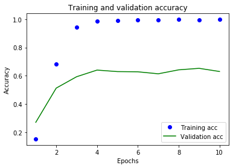

```python
import matplotlib.pyplot as plt
Tra_acc = History1.history['accuracy']
val_acc = History1.history['val_accuracy']

epochs = range(1, len(Tra_acc) + 1)

plt.plot(epochs, Tra_acc, 'bo', label='Training acc')
plt.plot(epochs, val_acc, 'g', label='Validation acc')
plt.title('Training and validation accuracy')
plt.xlabel('Epochs')
plt.ylabel('Accuracy')
plt.legend()
plt.show()
```

#### Visuallization of Training & validation loss

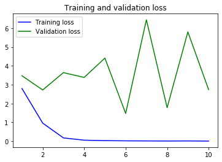

```python
loss = History1.history['loss']
val_loss = History1.history['val_loss']
plt.plot(epochs, loss, 'b', label='Training loss')
plt.plot(epochs, val_loss, 'g', label='Validation loss')
plt.title('Training and validation loss')
plt.legend()
plt.show()
```

### Observation after analysing Training & velidation loss, Accuracy(here we can check overfitting/underfitting)

A model that is underfit will have high training and high testing error while an overfit model will have extremely low training error but a high testing error.

```python
"""import numpy as np
from keras.preprocessing.image import ImageDataGenerator
test_dg = ImageDataGenerator(horizontal_flip=True)
test_generator=test_dg.flow_from_directory(r'C:\Users\Radhakrishna\asl_alphabet_test/asl_alphabet_test',target_size=(150, 150),class_mode='categorical')
test_generator.reset()"""
```

[output not shown]

```python
for layer in model.layers:
    print(layer.name)
    if 'Conv' not  in layer.name:
        continue
    f ,b= layer.get_weights()
    print(f.shape)
filters,bais = model.layers[2].get_weights()
print(filters.shape)
```

```
conv2d_35
max_pooling2d_73
Conv2a
(5, 5, 32, 48)
batch_normalization_26
max_pooling2d_74
Conv2b
(3, 3, 48, 64)
max_pooling2d_75
flatten_25
dense_73
dense_74
dense_75
(5, 5, 32, 48)
```

#### Retrieve weights from the second hidden layer

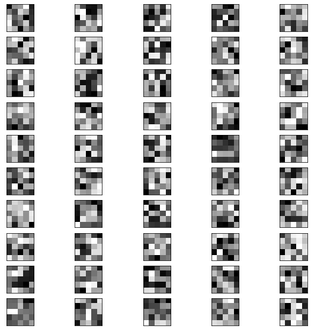

```python
from matplotlib import pyplot

# retrieve weights from the second hidden layer

#get_weights()-returns the weights of the layer as a list of Numpy arrays
filters, biases = model.layers[2].get_weights()
# normalize filter values to 0-1 so we can visualize them
f_min, f_max = filters.min(), filters.max()
filters = (filters - f_min) / (f_max - f_min)
# plot first few filters
n_filters, ix = 10, 1
pyplot.figure(figsize=(10,10))
for i in range(n_filters):
	# get the filter
	f = filters[:, :, :, i]
	# plot each channel separately
	for j in range(5):
		# specify subplot and turn of axis
		ax = pyplot.subplot(n_filters, 5, ix)
		ax.set_xticks([])
		ax.set_yticks([])
		# plot filter channel in grayscale
		pyplot.imshow(f[:, :, j], cmap='gray')
		ix += 1
# show the figure
pyplot.show()
```

# Evaluate the Model

```python
#Evaluates the model on a data generator.
score=model.evaluate_generator(validation_generator)
print("loss = ",score[0])
print("Accuracy = ",score[1])
```

```
loss =  2.0529611110687256
Accuracy =  0.6303871273994446
```

# Prediction

```python
pred=model.predict_generator(validation_generator)
#You need to reset the test_generator before whenever you call the predict_generator.
##This is important, if you forget to reset the test_generator you will get outputs in a weird order.
validation_generator.reset()
print('Prediction\n',pred[0, 0:29])
model.eva
```

```
Prediction
 [5.93928509e-12 1.90401933e-25 3.11090833e-33 5.42610661e-13
 4.80746909e-12 9.76872817e-03 5.15527741e-36 0.00000000e+00
 2.56392713e-10 1.72448922e-23 8.01917273e-21 9.90230620e-01
 2.94789277e-15 1.10195956e-29 5.64955485e-07 0.00000000e+00
 4.16345038e-29 4.00188052e-34 1.10307263e-09 5.80571354e-18
 1.19345164e-25 7.89940101e-20 9.35176311e-11 2.49131436e-20
 3.59594975e-18 2.34262396e-20 1.53645992e-27 0.00000000e+00
 6.25697907e-35]
```

```python
#from matplotlib import pyplot
#fig, ((ax1,ax2),(ax3,ax4))=pyplot.subplot(2,2)
#ax1.imshow(test_)
```

```python
#predictions=model.predict_classes(x_val[0:4,:,:,:])
```

```python
import numpy as np
#now predicted_class_indices has the predicted labels,
##but you can’t simply tell what the predictions are, because all you can see is numbers like 0,1,4,1,0,6…
#pred2=predicted_class_indices=np.argmax(pred,axis=1)
#print("predicted_class_indices",pred2)
```

[output not shown]

observation-

Since we are evaluating the model, we should treat the validation set as if it was the test set. So we should sample the images in the validation set exactly once(if you are planning to evaluate, you need to change the batch size of the valid generator to 1 or something that exactly divides the total num of samples in validation set), but the order doesn’t matter so let “shuffle” be True as it was earlier.

```python
#so we need to map the predicted labels with their unique ids such as filenames to find out what you predicted for which image
originalIndices = (train_generator.class_indices)
print("Original dict ", originalIndices)#will give original dictonary from the train generator
reversedIndices = dict((v,k) for k,v in labels.items())
print("Reversed dict ", reversedIndices)#will give original dictonary from the train generator
#Alpha = [labels[k] for k in predicted_class_indices]
#print(predictions)
```

[output not shown]

```
(15, 200, 200, 3)
```

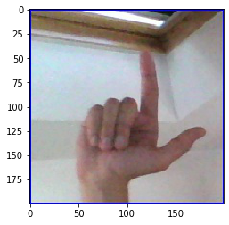

```
Expected y_val[image_index] is  [0. 0. 0. 0. 0. 0. 0. 0. 0. 0. 0. 1. 0. 0. 0. 0. 0. 0. 0. 0. 0. 0. 0. 0.
 0. 0. 0. 0. 0.]
Predicted Index >  [11]
Predicted Class is >  L
```

```python
image_index =8

#importing pyplot from matplot pakage
from matplotlib import pyplot
#imshow is attribute of pyplot which use to show image
pyplot.imshow(x_val[image_index].astype('int'))
print(x_val.shape)
pyplot.show()
#print("image show:",predictions[p14])
print("Expected y_val[image_index] is ", y_val[image_index])

predictions=model.predict_classes(x_val[image_index:image_index+1,:,:,:])
print("Predicted Index > ", predictions)
predicted_class = reversedIndices[predictions[0]]
print("Predicted Class is > ", predicted_class)
```